# Emmanuel_Itsuokor_8936753

### The scatter plot of the median house value vs the population shows the relationship between the housing prices in an area and the number of people living in that given area. this shows a weak relationship unlike our first scatter plot of house value vs population because it doesn't show if the house prices are affected by the size in population. the linear regression would most likely show that the population size as a factor doesnt play so much role in the prediction of house prices.

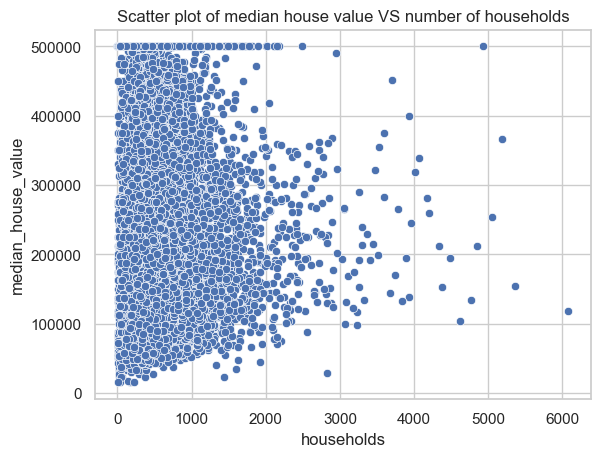

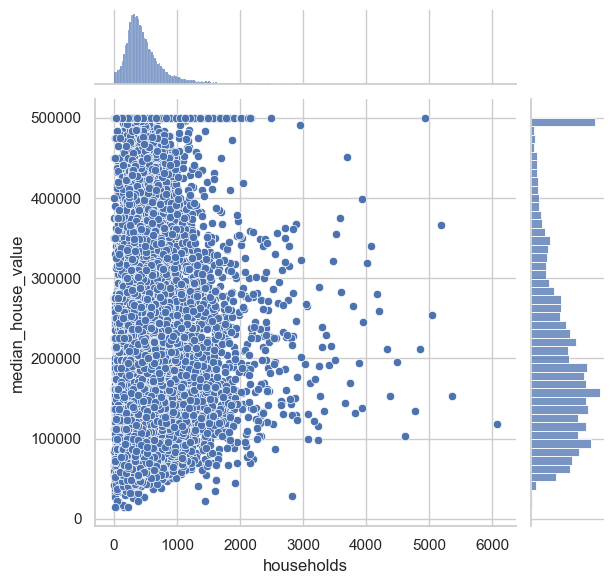

```python
## Scatter plot for median house value vs number of households
# Setting the size of the scatter plot


## Creating the scatter plot
sns.scatterplot(x="households", y="median_house_value", data=df)

## Adding a title to the plot
plt.title("Scatter plot of median house value VS number of households")

## seaborn scatter plot of the median_house_value vs number of households

sns.set(style="whitegrid", color_codes=True)
sns.jointplot(x="households", y="median_house_value", data=df)
```

## 4. Linear Regression

#### We have to filter out the records with the median value

```python
df_filter = df[df.median_house_value != 500001]
```

```python
print(f"After filtering, there are {len(df_filter)} records, versus {len(df)} before filtering")
```

```
After filtering, there are 19675 records, versus 20640 before filtering
```

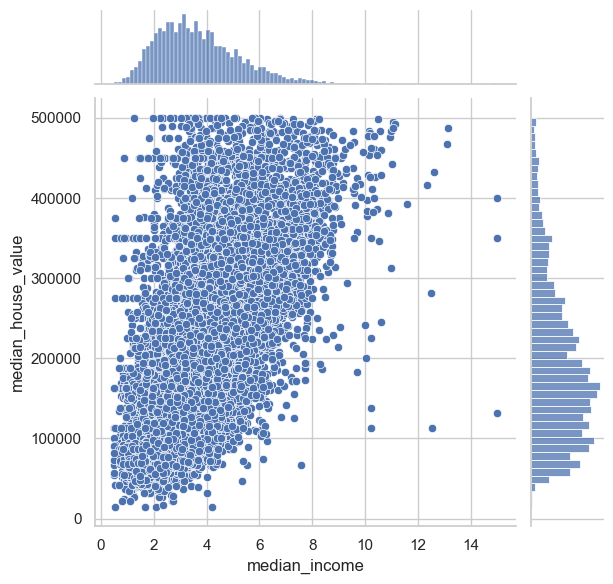

```python
## Visualizing the difference using scatter plot
sns.set(style="whitegrid", color_codes=True)
sns.jointplot(x="median_income", y="median_house_value", data=df_filter)
```

### First we split the data into training and test sets, then we use the first 80% of the data for training.

```python
## Training and testing
train_size = int(len(df_filter) * 0.8)
train = df_filter[:train_size]
test = df_filter[train_size:]
```

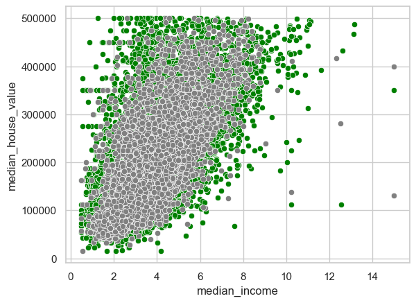

```python
## Scatter plot to show the train set in green and test set in gray on the same plot for median_income vs median house value
sns.scatterplot(x="median_income", y="median_house_value", data=train, color="green")
sns.scatterplot(x="median_income", y="median_house_value", data=test, color="gray")
```

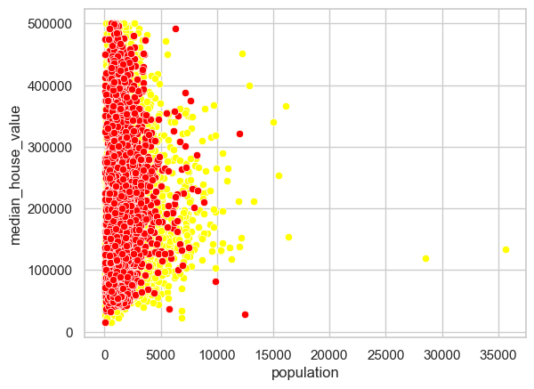

```python
## Scatter plot to show the train set in green and test set in gray on the same plot for population vs median house value
sns.scatterplot(x="population", y="median_house_value", data=train, color="yellow")
sns.scatterplot(x="population", y="median_house_value", data=test, color="red")
```

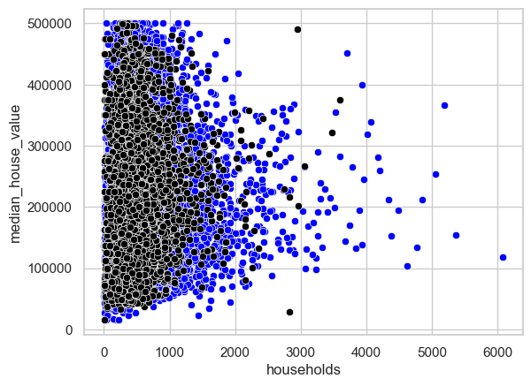

```python
## Scatter plot to show the train set in green and test set in gray on the same plot for number of households vs median house value
sns.scatterplot(x="households", y="median_house_value", data=train, color="blue")
sns.scatterplot(x="households", y="median_house_value", data=test, color="black")
```

### Defining the model

```python
## Importing the necessay library needed to define the model
from sklearn import linear_model
from sklearn.metrics import mean_squared_error, mean_absolute_error


## Creating a linear regression object
model = linear_model.LinearRegression()
```

### Training the model

```python
## Training the model for median income vs median house value (Fit)
model.fit(X=train[["median_income"]], y=train[["median_house_value"]])

## Intercept of the model
intercept_i = model.intercept_
print("intercept:",intercept_i)

## Slope of the model
slope_i = model.coef_[0]
print("slope:",slope_i)

## Prediction of model
y=train[["median_house_value"]]
y_predict_i = model.predict(X=train[["median_income"]])

## Calculating the mean squared error
mse_i = mean_squared_error(y,y_predict_i)
print("MSE:",mse_i)

## calculating the mean absolute error
mae_i = mean_absolute_error(y,y_predict_i)
print("MAE:",mae_i)

## mse for test set
y=test[["median_house_value"]]
y_predict_ii = model.predict(X=test[["median_income"]])
mse_ii = mean_squared_error(y,y_predict_ii)
print("MSE on test set:",mse_ii)

## mae for test set
mae_ii = mean_absolute_error(y,y_predict_ii)
print("MAE on test set:",mae_ii)
```

```
intercept: [48204.53436817]
slope: [38702.97233842]
MSE: 5557954319.259176
MAE: 55839.99864072871
MSE on test set: 5831038297.419372
MAE on test set: 59961.60099129183
```

```python
## Training the model for population vs median house value (Fit)

model.fit(X=train[["population"]], y=train[["median_house_value"]])
intercept_p = model.intercept_
print(intercept_p)

## Slope of the model
slope_p = model.coef_[0]
print("slope:",slope_p)

## Prediction of model
y=train[["median_house_value"]]
y_predict_p= model.predict(X=train[["population"]])

## Calculating the mean squared error
mse_p = mean_squared_error(y,y_predict_p)
print("MSE:",mse_p)

## calculating the mean absolute error
mae_p = mean_absolute_error(y,y_predict_p)
print("MAE:",mae_p)

## mse for test set
y=test[["median_house_value"]]
y_predict_pp = model.predict(X=test[["population"]])
mse_pp = mean_squared_error(y,y_predict_pp)
print("MSE on test set:",mse_pp)

## mae for test set
mae_pp = mean_absolute_error(y,y_predict_pp)
print("MAE on test set:",mae_pp)
```

```
[188081.58862584]
slope: [0.32862973]
MSE: 9236185598.969007
MAE: 75879.52660618868
MSE on test set: 10863782849.78328
MAE on test set: 85178.9089807831
```

```python
## Training the model for number of households vs median house value (Fit)
model.fit(X=train[["households"]], y=train[["median_house_value"]])
intercept_h = model.intercept_
print(intercept_h)

## Slope of the model
slope_h = model.coef_[0]
print("slope:",slope_h)

## Prediction of model
y=train[["median_house_value"]]
y_predict_h = model.predict(X=train[["households"]])

## Calculating the mean squared error
mse_h = mean_squared_error(y,y_predict_h)
print("MSE:",mse_h)

## calculating the mean absolute error
mae_h = mean_absolute_error(y,y_predict_h)
print("MAE:",mae_h)

## mse for test set
y=test[["median_house_value"]]
y_predict_hh = model.predict(X=test[["households"]])
mse_hh = mean_squared_error(y,y_predict_hh)
print("MSE on test set:",mse_hh)

## mae for test set
mae_hh = mean_absolute_error(y,y_predict_hh)
print("MAE on test set:",mae_hh)
```

```
[177147.28853835]
slope: [22.62572591]
MSE: 9156895298.287685
MAE: 75463.10651473372
MSE on test set: 10759278800.526697
MAE on test set: 84503.1472350856
```

```python
## Creating a table to summarize results
results = {
'Model': ['median_income','Population','Households'],
'Intercept': [intercept_i,intercept_p,intercept_h],
'Slope':[slope_i,slope_p,slope_h],
'Mean Squared Error for train set': [mse_i,mse_p,mse_h],
'Mean Squared Error for train set': [mae_i,mae_p,mae_h],
'Mean Squared Error for test set': [mse_ii,mse_pp,mse_hh],
'Mean Absolute Error on test set': [mae_ii,mae_pp,mae_hh]
}

## Converting to a dataframe
result_df = pd.DataFrame(results)
print(result_df)
```

[output not shown]

## Regression line on each models

#### 1. Regression graphs on trained sets

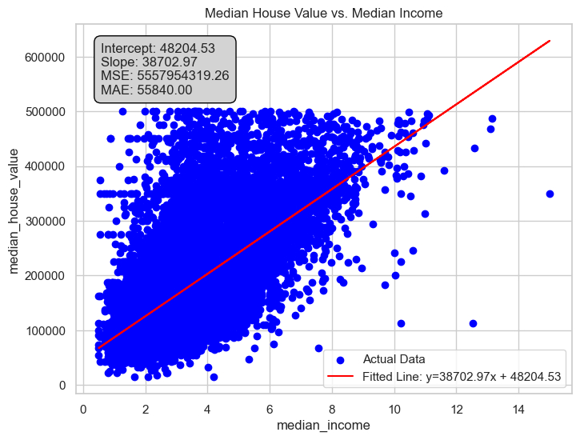

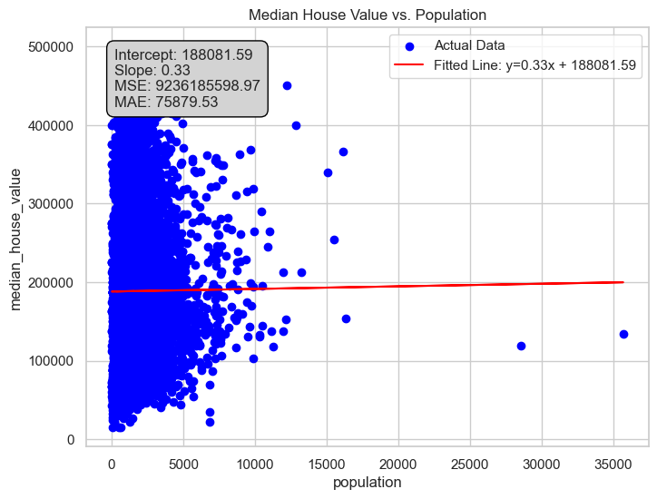

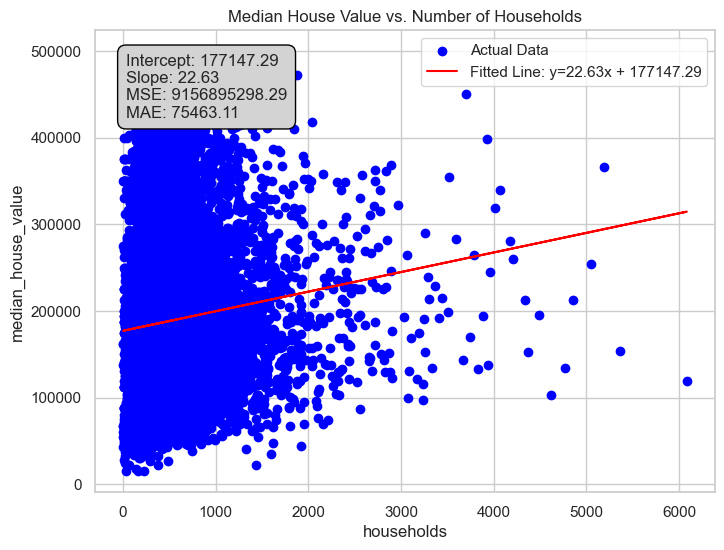

```python
def plot_model_fixed(train, x_col, y_col, y_pred, intercept, slope, mse, mae, title):
   plt.figure(figsize=(8,6))
   plt.scatter(train[x_col], train[y_col], color="blue", label="Actual Data")
   plt.plot(train[x_col], y_pred, color="red", label=f"Fitted Line: y={slope[0]:.2f}x + {intercept:.2f}")
   plt.title(title)
   plt.xlabel(x_col)
   plt.ylabel(y_col)
   plt.legend()

   # Add text box with model parameters
   textstr = f'Intercept: {intercept:.2f}\nSlope: {slope[0]:.2f}\nMSE: {mse:.2f}\nMAE: {mae:.2f}'
   plt.gca().text(0.05, 0.95, textstr, transform=plt.gca().transAxes, fontsize=12,
                  verticalalignment='top', bbox=dict(boxstyle='round,pad=0.5', edgecolor='black', facecolor='lightgrey'))

   plt.show()

# Plot for Median House Value vs. Median Income
plot_model_fixed(train, "median_income", "median_house_value", y_predict_i, intercept_i[0], slope_i, mse_i, mae_i, "Median House Value vs. Median Income")

# Plot for Median House Value vs. Population
plot_model_fixed(train, "population", "median_house_value", y_predict_p, intercept_p[0], slope_p, mse_p, mae_p, "Median House Value vs. Population")

# Plot for Median House Value vs. Number of Households
plot_model_fixed(train, "households", "median_house_value", y_predict_h, intercept_h[0], slope_h, mse_h, mae_h, "Median House Value vs. Number of Households")
```

#### 2. Regression model on test sets

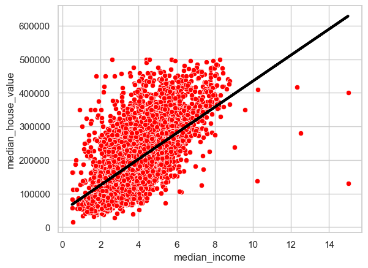

```python
# Train the model using 'median_income' as the feature
X_income = train[["median_income"]]
y_house_value = train["median_house_value"]

model_income = linear_model.LinearRegression()
model_income.fit(X_income, y_house_value)
# Predict using the 'median_income' model
plt.plot(test[["median_income"]], model_income.predict(test[["median_income"]]), color="black", linewidth=3)

# Plot scatter plot
sns.scatterplot(x="median_income", y="median_house_value", data=test, color='red')
plt.show()
```

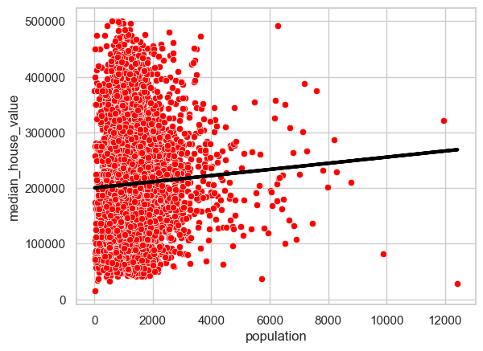

```python
# Use population as the feature for training
X_population = test[["population"]]  # 2D array with population as the feature
y_house_value = test["median_house_value"]  # Target

model_population = linear_model.LinearRegression()
model_population.fit(X_population, y_house_value)

# Predict using the population feature
plt.plot(test[["population"]], model_population.predict(test[["population"]]), color="black", linewidth=3)

# Show the scatter plot and regression line
sns.scatterplot(x="population", y="median_house_value", data=test, color="red")
plt.show()
```

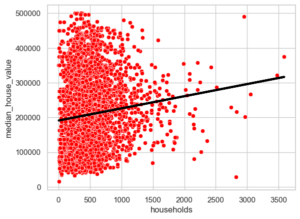

```python
# Use households as the feature for training
X_households = test[["households"]]  # 2D array with households as the feature
y_house_value = test["median_house_value"]  # Target

# Train a new model with households as the feature
model_households = linear_model.LinearRegression()
model_households.fit(X_households, y_house_value)

# Predict using the households feature
plt.plot(test[["households"]], model_households.predict(test[["households"]]), color="black", linewidth=3)

# Show the scatter plot and regression line
sns.scatterplot(x="households", y="median_house_value", data=test, color="red")
plt.show()
```

## **Conclusion**

### The goal of this report is to dive into the relationship between the several housing factors in this use case and how they play different roles in affecting the housing market. in this report. we trained three different linear regression models on their train and test dataset. the variables present in this linear regression model were

### a. Median house value- which is a dependent variable because it depends on the other housing factors

### b. Median income- Independent variable

### c. Population- Independent variable

### d. Number of households- Independent variable.

### Goodness of Fit:The term goodness-of-fit refers to a statistical test that determines how well sample data fits a distribution from a population with a normal distribution. Put simply, it hypothesizes whether a sample is skewed or represents the data you would expect to find in the actual population.(https://www.investopedia.com/terms/g/goodness-of-fit.) Looking at their goodness of fit, the Mean squared value (MSE) represents the average difference squared of the actual value minus the predicted value. so a lower MSE indicates a better fit.

### Also, the Mean Absolute error (MAE) represents the average absolute difference between the actual and predicted values and in this case the lower values are betetr than the higher values. in this case looking at the goodness of fit, the best model is the Median income,the normal model which is pretty moderate is the number of households, and the population model is the weakest out of all these models.